# Loading Libraries and Dataset

```python
import pandas as pd
import numpy as np
import matplotlib.pyplot as plt
import seaborn as sb
```

```python
dfx = pd.read_excel('/Movie300 Revised V2.xlsx')
dfx.head()
```

|  | Movie_name | Movie_Genre | Movie_Genre_Num | Movie_Certification | Movie_Certification_Num | Release_Date | Release_Month | Release_Month_Num | Runtime_Duration | Runtime_Minutes | Movie_Directors | Music_Directors | Lead_Actor | Lead_Actress | Movie_Critic_Rating | Movie_User_Rating | Movie_Synopsis | Movie_Full_Cast |
| --- | --- | --- | --- | --- | --- | --- | --- | --- | --- | --- | --- | --- | --- | --- | --- | --- | --- | --- |
| 0 | Kannum Kannum Kollaiyadithaal | Thriller | 15 | U | 2 | 28 Feb 2020 | Feb | 2 | 02:02:00 | 122 | Desingh Periyasamy | D Imman | Dulquer Salmaan | Ritu Varma | 3.5 | 3.4 | Desingh Periyasamy displays a flair for this m... | Dulquer Salmaan, Ritu Varma, Gautham Vasudev M... |
| 1 | Oh My Kadavule | Comedy | 14 | UA | 1 | 14 Feb 2020 | Feb | 2 | 02:31:00 | 151 | Ashwath Marimuthu | Leon James | Ashok Selvan | Ritika Singh | 3.5 | 3.4 | Despite some conventional turns, Oh My Kadavul... | Ashok Selvan, Ritika Singh, Vani Bhojan |
| 2 | Psycho | Thriller | 15 | A | 3 | 24 Jan 2020 | Jan | 1 | 02:14:00 | 134 | Mysskin | Ilayaraja | Udhayanidhi Stalin | Aditi Rao Hydari | 3.5 | 3.3 | First-rate filmmaking combines with perceptive... | Udhayanidhi Stalin, Aditi Rao Hydari, Nithya M... |
| 3 | Dharala Prabhu | Comedy | 14 | UA | 1 | 13 Mar 2020 | Mar | 3 | 02:02:00 | 122 | Krishna Marimuthu | Anirudh Ravichander | Harish Kalyan | Tanya Hope | 3.0 | 3.3 | A better background score and more effort on t... | Harish Kalyan, Tanya Hope, Vivek |
| 4 | Gypsy | Drama | 17 | UA | 1 | 06 Mar 2020 | Mar | 3 | 02:25:00 | 145 | Raju Murugan | Santhosh Narayanan | Jiiva | Natasha Singh | 3.0 | 3.2 | Gypsy which talks about the politicisation of ... | Jiiva, Natasha Singh, Lal Jose, Sunny Wayne |

# Dataset Cleaning and some preliminary steps

```python
dfx['Release_Month'] = dfx['Release_Date'].apply(lambda x: x.split(' ')[1])
dfx['Release_Month'].head()
```

```
0    Feb
1    Feb
2    Jan
3    Mar
4    Mar
Name: Release_Month, dtype: object
```

```python
dfx.info()
```

```
<class 'pandas.core.frame.DataFrame'>
RangeIndex: 300 entries, 0 to 299
Data columns (total 18 columns):
 #   Column                   Non-Null Count  Dtype
---  ------                   --------------  -----
 0   Movie_name               300 non-null    object
 1   Movie_Genre              300 non-null    object
 2   Movie_Genre_Num          300 non-null    int64
 3   Movie_Certification      300 non-null    object
 4   Movie_Certification_Num  300 non-null    int64
 5   Release_Date             300 non-null    object
 6   Release_Month            300 non-null    object
 7   Release_Month_Num        300 non-null    int64
 8   Runtime_Duration         300 non-null    object
 9   Runtime_Minutes          300 non-null    int64
 10  Movie_Directors          300 non-null    object
 11  Music_Directors          298 non-null    object
 12  Lead_Actor               300 non-null    object
 13  Lead_Actress             300 non-null    object
 14  Movie_Critic_Rating      300 non-null    float64
 15  Movie_User_Rating        300 non-null    float64
 16  Movie_Synopsis           300 non-null    object
 17  Movie_Full_Cast          300 non-null    object
dtypes: float64(2), int64(4), object(12)
memory usage: 42.3+ KB
```

```python
dfx.fillna
```

```
<bound method DataFrame.fillna of                         Movie_name  ...                                    Movie_Full_Cast
0    Kannum Kannum Kollaiyadithaal  ...  Dulquer Salmaan, Ritu Varma, Gautham Vasudev M...
1                   Oh My Kadavule  ...            Ashok Selvan, Ritika Singh, Vani Bhojan
2                           Psycho  ...  Udhayanidhi Stalin, Aditi Rao Hydari, Nithya M...
3                   Dharala Prabhu  ...                   Harish Kalyan, Tanya Hope, Vivek
4                            Gypsy  ...        Jiiva, Natasha Singh, Lal Jose, Sunny Wayne
..                             ...  ...                                                ...
295                   Nootrenbadhu  ...  Siddharth, Priya Anand, Nithya Menen, Mouli, G...
296                 Ponnar Shankar  ...  Prashanth, Divya Parameswaran, Pooja Chopra, S...
297               Nadunisi Naaygal  ...         Veera, Sameera Reddy, Deva, Swapna Abraham
298                       Ilaignan  ...  Pa Vijay, Kushboo, Meera Jasmine, Ramya Nambee...
299                      Mappillai  ...  Dhanush, Hansika Motwani, Manisha Koirala, Viv...

[300 rows x 18 columns]>
```

```python
dfx.info()
```

```
<class 'pandas.core.frame.DataFrame'>
RangeIndex: 300 entries, 0 to 299
Data columns (total 18 columns):
 #   Column                   Non-Null Count  Dtype
---  ------                   --------------  -----
 0   Movie_name               300 non-null    object
 1   Movie_Genre              300 non-null    object
 2   Movie_Genre_Num          300 non-null    int64
 3   Movie_Certification      300 non-null    object
 4   Movie_Certification_Num  300 non-null    int64
 5   Release_Date             300 non-null    object
 6   Release_Month            300 non-null    object
 7   Release_Month_Num        300 non-null    int64
 8   Runtime_Duration         300 non-null    object
 9   Runtime_Minutes          300 non-null    int64
 10  Movie_Directors          300 non-null    object
 11  Music_Directors          298 non-null    object
 12  Lead_Actor               300 non-null    object
 13  Lead_Actress             300 non-null    object
 14  Movie_Critic_Rating      300 non-null    float64
 15  Movie_User_Rating        300 non-null    float64
 16  Movie_Synopsis           300 non-null    object
 17  Movie_Full_Cast          300 non-null    object
dtypes: float64(2), int64(4), object(12)
memory usage: 42.3+ KB
```

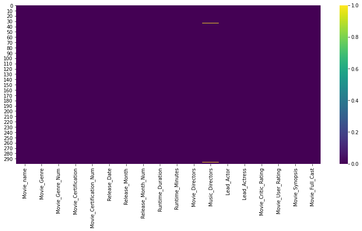

```python
plt.figure(figsize=(14,6))
sb.heatmap(dfx.isnull(), cmap="viridis")
```

```python
dfx['Lead_Actor'].isnull().sum()
```

```
0
```

```python
dfx['Lead_Actress'].isnull().sum()
```

```
0
```

```python
dfy = dfx.copy()
```

```python
dfy.head()
```

|  | Movie_name | Movie_Genre | Movie_Genre_Num | Movie_Certification | Movie_Certification_Num | Release_Date | Release_Month | Release_Month_Num | Runtime_Duration | Runtime_Minutes | Movie_Directors | Music_Directors | Lead_Actor | Lead_Actress | Movie_Critic_Rating | Movie_User_Rating | Movie_Synopsis | Movie_Full_Cast |
| --- | --- | --- | --- | --- | --- | --- | --- | --- | --- | --- | --- | --- | --- | --- | --- | --- | --- | --- |
| 0 | Kannum Kannum Kollaiyadithaal | Thriller | 15 | U | 2 | 28 Feb 2020 | Feb | 2 | 02:02:00 | 122 | Desingh Periyasamy | D Imman | Dulquer Salmaan | Ritu Varma | 3.5 | 3.4 | Desingh Periyasamy displays a flair for this m... | Dulquer Salmaan, Ritu Varma, Gautham Vasudev M... |
| 1 | Oh My Kadavule | Comedy | 14 | UA | 1 | 14 Feb 2020 | Feb | 2 | 02:31:00 | 151 | Ashwath Marimuthu | Leon James | Ashok Selvan | Ritika Singh | 3.5 | 3.4 | Despite some conventional turns, Oh My Kadavul... | Ashok Selvan, Ritika Singh, Vani Bhojan |
| 2 | Psycho | Thriller | 15 | A | 3 | 24 Jan 2020 | Jan | 1 | 02:14:00 | 134 | Mysskin | Ilayaraja | Udhayanidhi Stalin | Aditi Rao Hydari | 3.5 | 3.3 | First-rate filmmaking combines with perceptive... | Udhayanidhi Stalin, Aditi Rao Hydari, Nithya M... |
| 3 | Dharala Prabhu | Comedy | 14 | UA | 1 | 13 Mar 2020 | Mar | 3 | 02:02:00 | 122 | Krishna Marimuthu | Anirudh Ravichander | Harish Kalyan | Tanya Hope | 3.0 | 3.3 | A better background score and more effort on t... | Harish Kalyan, Tanya Hope, Vivek |
| 4 | Gypsy | Drama | 17 | UA | 1 | 06 Mar 2020 | Mar | 3 | 02:25:00 | 145 | Raju Murugan | Santhosh Narayanan | Jiiva | Natasha Singh | 3.0 | 3.2 | Gypsy which talks about the politicisation of ... | Jiiva, Natasha Singh, Lal Jose, Sunny Wayne |

```python
dfy.dropna(inplace=True)
```

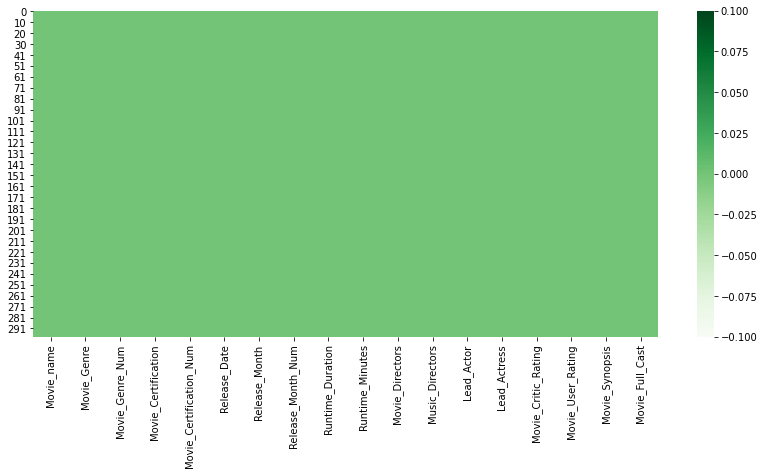

```python
plt.figure(figsize=(14,6))
sb.heatmap(dfy.isnull(), cmap="Greens")

#'Accent', 'Accent_r', 'Blues', 'Blues_r', 'BrBG', 'BrBG_r', 'BuGn', 'BuGn_r', 'BuPu', 'BuPu_r', 'CMRmap',
#'CMRmap_r', 'Dark2', 'Dark2_r', 'GnBu', 'GnBu_r', 'Greens', 'Greens_r', 'Greys', 'Greys_r', 'OrRd', 'OrRd_r',
#'Oranges', 'Oranges_r', 'PRGn', 'PRGn_r', 'Paired', 'Paired_r', 'Pastel1', 'Pastel1_r', 'Pastel2', 'Pastel2_r',
#'PiYG', 'PiYG_r', 'PuBu', 'PuBuGn', 'PuBuGn_r', 'PuBu_r', 'PuOr', 'PuOr_r', 'PuRd', 'PuRd_r', 'Purples', 'Purples_r',
#'RdBu', 'RdBu_r', 'RdGy', 'RdGy_r', 'RdPu', 'RdPu_r', 'RdYlBu', 'RdYlBu_r', 'RdYlGn', 'RdYlGn_r', 'Reds', 'Reds_r',
#'Set1', 'Set1_r', 'Set2', 'Set2_r', 'Set3', 'Set3_r', 'Spectral', 'Spectral_r', 'Wistia', 'Wistia_r', 'YlGn', 'YlGnBu',
#'YlGnBu_r', 'YlGn_r', 'YlOrBr', 'YlOrBr_r', 'YlOrRd', 'YlOrRd_r', 'afmhot', 'afmhot_r', 'autumn', 'autumn_r', 'binary',
#'binary_r', 'bone', 'bone_r', 'brg', 'brg_r', 'bwr', 'bwr_r', 'cividis', 'cividis_r', 'cool', 'cool_r', 'coolwarm',
#'coolwarm_r', 'copper', 'copper_r', 'cubehelix', 'cubehelix_r', 'flag', 'flag_r', 'gist_earth', 'gist_earth_r',
#'gist_gray', 'gist_gray_r', 'gist_heat', 'gist_heat_r', 'gist_ncar', 'gist_ncar_r', 'gist_rainbow', 'gist_rainbow_r',
#'gist_stern', 'gist_stern_r', 'gist_yarg', 'gist_yarg_r', 'gnuplot', 'gnuplot2', 'gnuplot2_r', 'gnuplot_r', 'gray',
#'gray_r', 'hot', 'hot_r', 'hsv', 'hsv_r', 'icefire', 'icefire_r', 'inferno', 'inferno_r', 'jet', 'jet_r', 'magma',
#'magma_r', 'mako', 'mako_r', 'n...
```

```python
dfy.info()
```

```
<class 'pandas.core.frame.DataFrame'>
Int64Index: 298 entries, 0 to 299
Data columns (total 18 columns):
 #   Column                   Non-Null Count  Dtype
---  ------                   --------------  -----
 0   Movie_name               298 non-null    object
 1   Movie_Genre              298 non-null    object
 2   Movie_Genre_Num          298 non-null    int64
 3   Movie_Certification      298 non-null    object
 4   Movie_Certification_Num  298 non-null    int64
 5   Release_Date             298 non-null    object
 6   Release_Month            298 non-null    object
 7   Release_Month_Num        298 non-null    int64
 8   Runtime_Duration         298 non-null    object
 9   Runtime_Minutes          298 non-null    int64
 10  Movie_Directors          298 non-null    object
 11  Music_Directors          298 non-null    object
 12  Lead_Actor               298 non-null    object
 13  Lead_Actress             298 non-null    object
 14  Movie_Critic_Rating      298 non-null    float64
 15  Movie_User_Rating        298 non-null    float64
 16  Movie_Synopsis           298 non-null    object
 17  Movie_Full_Cast          298 non-null    object
dtypes: float64(2), int64(4), object(12)
memory usage: 44.2+ KB
```

# Genre Analysis

```python
dfx['Movie_Genre'].unique()
```

```
array(['Thriller', 'Comedy', 'Drama', 'Action', 'Family', 'Crime',
       'Adventure', 'Musical', 'Biography', 'Sports', 'Romance', 'Sci-Fi',
       'Mystery', 'Horror', 'Documentary', 'History', 'Fantasy'],
      dtype=object)
```

```python
genre = dfx.groupby('Movie_Genre')['Movie_Genre'].count()
genre
```

```
Movie_Genre
Action          52
Adventure        2
Biography        2
Comedy          31
Crime           10
Documentary      1
Drama          100
Family           2
Fantasy          2
History          3
Horror          11
Musical          2
Mystery          3
Romance         29
Sci-Fi           5
Sports           4
Thriller        41
Name: Movie_Genre, dtype: int64
```

**Pie Chart Representation of basic genre**

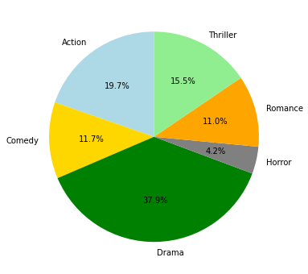

```python
genre_general = ['Action', 'Comedy', 'Drama', 'Horror', 'Romance', 'Thriller']
genre_general_values = [52, 31, 100, 11, 29, 41]

#pie chart
colors = ['lightblue', 'gold', 'green','grey', 'orange', 'lightgreen' ]
plt.subplots(figsize=(14,6))
plt.pie(genre_general_values,labels=genre_general, colors=colors, startangle = 90, autopct='%.1f%%')
plt.show()
```

**Bar Chart Representation of basic genre**

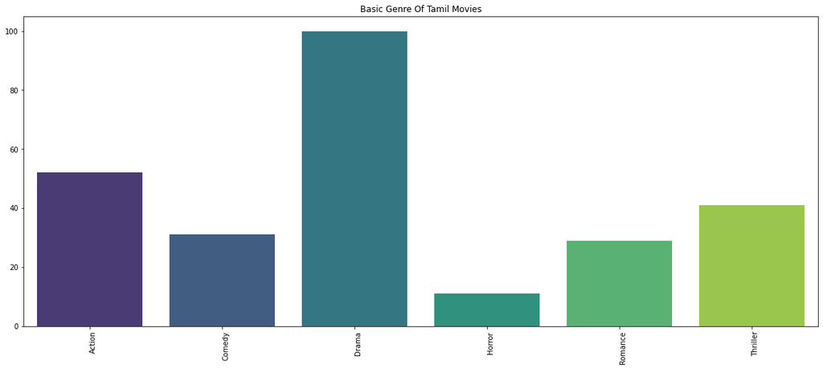

```python
plt.figure(figsize=(20,8))
x = genre_general
y = genre_general_values
chart1 = sb.barplot(x, y, palette='viridis')
chart1.set_xticklabels(chart1.get_xticklabels(), rotation=90, horizontalalignment='left')
chart1.set_title('Basic Genre Of Tamil Movies')
plt.show()
```

**Depth Analysis of Genre**

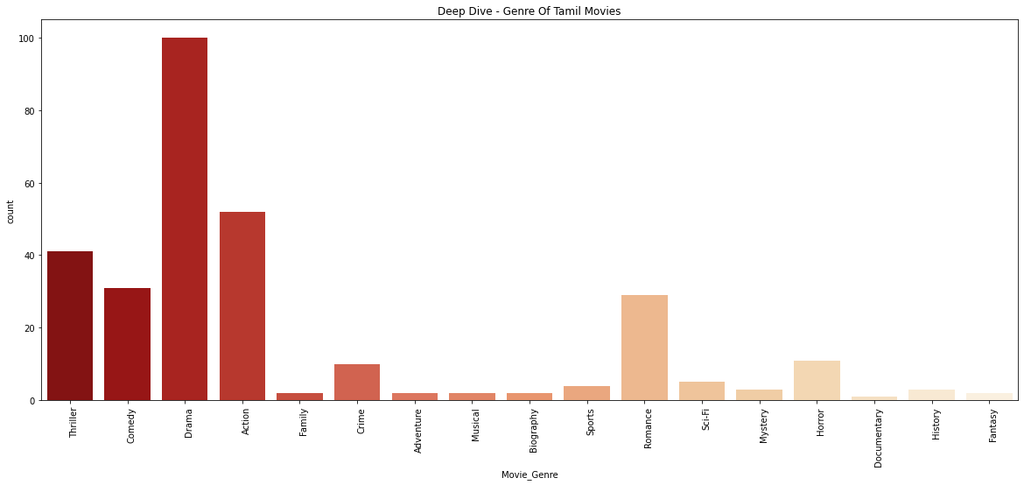

```python
plt.figure(figsize=(20,8))
x = dfx['Movie_Genre']
chart1 = sb.countplot(x, data=dfx, palette='OrRd_r')
chart1.set_xticklabels(chart1.get_xticklabels(), rotation=90, horizontalalignment='left')
chart1.set_title('Deep Dive - Genre Of Tamil Movies')
plt.show()
```

# Month-wise Visualization of Movie releases

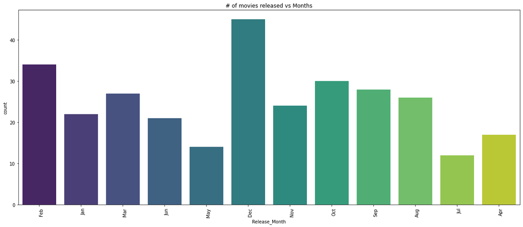

```python
plt.figure(figsize=(20,8))
chart1 = sb.countplot(x=dfx['Release_Month'], data=dfx, palette='viridis')
chart1.set_xticklabels(chart1.get_xticklabels(), rotation=90, horizontalalignment='left')
chart1.set_title('# of movies released vs Months')
plt.show()
```

# User Rating Distribution Plot

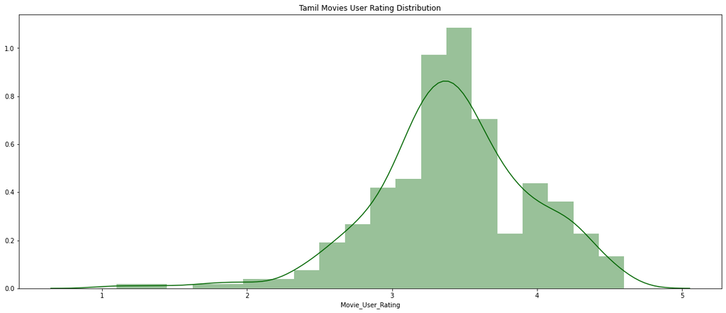

```python
plt.figure(figsize=(20,8))
chart2 = sb.distplot(dfx['Movie_User_Rating'],  color="#006600")
chart2.set_title('Tamil Movies User Rating Distribution')
plt.show()
```

# Movie Certifications Analysis

**Pie Chart Representation of Movie Censorboard Certification**

```python
mc = dfx.groupby('Movie_Certification')['Movie_Certification'].count()
mc_entities = ['UA', 'U', 'A']
mc_values = [242,49,9]
```

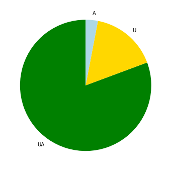

```python
plt.subplots(figsize=(14,6))
colors = ['green', 'gold', 'lightblue']
plt.pie(mc_values, labels = mc_entities, colors=colors, startangle = 90)
plt.show()
```

# Analysis of Lead Actors and Lead Actresses of the Decade

**Dominance comparison of Lead Actors**

```python
dfx['Lead_Actor'].nunique()
```

```
131
```

NML - No specific male lead. Indicates the presence of successful movies with only female lead.

NFL - No specific female lead.

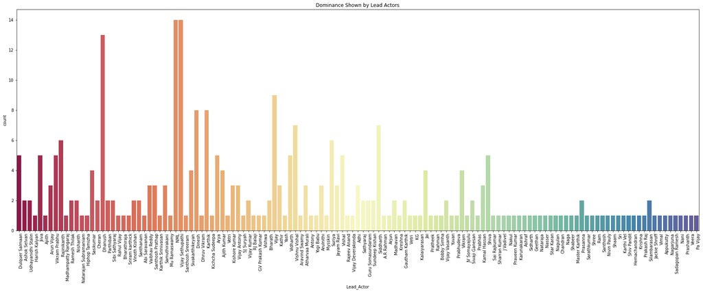

```python
plt.figure(figsize=(30,10))
chart1 = sb.countplot(x=dfx['Lead_Actor'], data=dfx, palette='Spectral')
chart1.set_xticklabels(chart1.get_xticklabels(), rotation=90, horizontalalignment='left')
chart1.set_title('Dominance Shown by Lead Actors')
plt.show()
```

**Dominance comparison of Lead Actresses**

```python
dfx['Lead_Actress'].nunique()
```

```
159
```

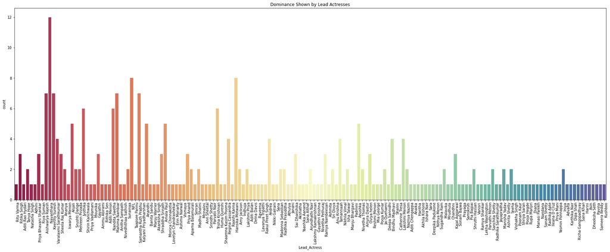

```python
plt.figure(figsize=(30,10))
chart1 = sb.countplot(x=dfx['Lead_Actress'], data=dfx, palette='Spectral')
chart1.set_xticklabels(chart1.get_xticklabels(), rotation=90, horizontalalignment='left')
chart1.set_title('Dominance Shown by Lead Actresses')
plt.show()
```

# Analysis of Movie Directors

```python
dfx['Movie_Directors'].nunique()
```

```
211
```

```python
'''plt.figure(figsize=(20,42))
chart1 = sb.countplot(y=dfx['Movie_Directors'], data=dfx, palette='viridis')
chart1.set_xticklabels(chart1.get_xticklabels(), rotation=90, horizontalalignment='left')
chart1.set_title('Graph representing Movie Directors')
plt.show()'''
```

```
"plt.figure(figsize=(20,42))\nchart1 = sb.countplot(y=dfx['Movie_Directors'], data=dfx, palette='viridis')\nchart1.set_xticklabels(chart1.get_xticklabels(), rotation=90, horizontalalignment='left')\nchart1.set_title('Graph representing Movie Directors')\nplt.show()"
```

```python
dirgroup = dfx.groupby('Movie_Directors')['Movie_Directors'].count()
d = dirgroup.to_frame()
d
```

| Movie_Directors | Movie_Directors |
| --- | --- |
| A G Amid | 1 |
| A L Abanindran | 1 |
| A L Vijay | 2 |
| A Raajdheep | 1 |
| A Sarkunam | 1 |
| ... | ... |
| Vijay Milton | 2 |
| Vikram Kumar | 1 |
| Vikram Sugumaran | 1 |
| Yuvaraj Dhayalan | 1 |
| Yuvaraj Subramani | 1 |

211 rows × 1 columns

```python
print(d.rename(columns={'Movie_Directors': 'Director', 'Movie_Directors': 'num_movies'}))
```

```
                   num_movies
Movie_Directors
A G Amid                    1
A L Abanindran              1
A L Vijay                   2
A Raajdheep                 1
A Sarkunam                  1
...                       ...
Vijay Milton                2
Vikram Kumar                1
Vikram Sugumaran            1
Yuvaraj Dhayalan            1
Yuvaraj Subramani           1

[211 rows x 1 columns]
```

```python
dx = d.rename(columns={'Movie_Directors': 'num_movies'}, index={'Movie_Directors': 'Directors'})
dx
```

| Movie_Directors | num_movies |
| --- | --- |
| A G Amid | 1 |
| A L Abanindran | 1 |
| A L Vijay | 2 |
| A Raajdheep | 1 |
| A Sarkunam | 1 |
| ... | ... |
| Vijay Milton | 2 |
| Vikram Kumar | 1 |
| Vikram Sugumaran | 1 |
| Yuvaraj Dhayalan | 1 |
| Yuvaraj Subramani | 1 |

211 rows × 1 columns

```python
dx.reset_index(level=0, inplace=True)
dx
```

|  | Movie_Directors | num_movies |
| --- | --- | --- |
| 0 | A G Amid | 1 |
| 1 | A L Abanindran | 1 |
| 2 | A L Vijay | 2 |
| 3 | A Raajdheep | 1 |
| 4 | A Sarkunam | 1 |
| ... | ... | ... |
| 206 | Vijay Milton | 2 |
| 207 | Vikram Kumar | 1 |
| 208 | Vikram Sugumaran | 1 |
| 209 | Yuvaraj Dhayalan | 1 |
| 210 | Yuvaraj Subramani | 1 |

211 rows × 2 columns

```python
dy = dx[dx.num_movies != 1]
```

```python
dy.head()
```

|  | Movie_Directors | num_movies |
| --- | --- | --- |
| 2 | A L Vijay | 2 |
| 6 | AR Murugadoss | 5 |
| 10 | Anand Shankar | 2 |
| 12 | Andrew Louis | 2 |
| 15 | Arivazhagan Venkatachalam | 2 |

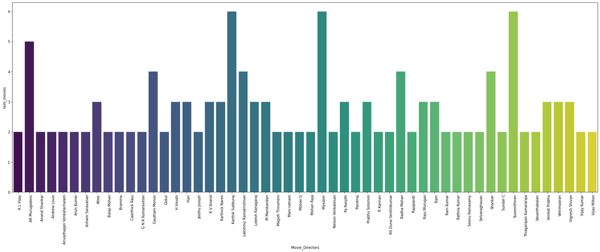

```python
plt.figure(figsize=(30,10))
chart1 = sb.barplot(x=dy['Movie_Directors'], y= dy['num_movies'], palette='viridis')
chart1.set_xticklabels(chart1.get_xticklabels(), rotation=90, horizontalalignment='left')
plt.show()
```

# Analysis of Music Directors

```python
dfx['Music_Directors'].nunique()
```

```
100
```

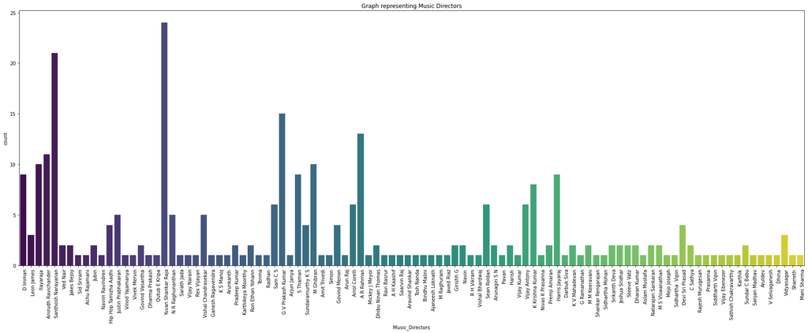

```python
plt.figure(figsize=(30,10))
chart1 = sb.countplot(x=dfx['Music_Directors'], data=dfx, palette='viridis')
chart1.set_xticklabels(chart1.get_xticklabels(), rotation=90, horizontalalignment='left')
chart1.set_title('Graph representing Music Directors')
plt.show()
```

# Derived Conclusions

Presenting the Rockstars of Kollywood in the decade 2011-2020

Most Dominating Lead Actor: Vijay Sethupathi

[figure not shown]

Most Dominating Lead Actress: Nayanthara

[figure not shown]

Best Director in Tamil Cinema - Genre: Thriller - Mysskin

[figure not shown]

Best Director in Tamil Cinema - Genre: Social Awarness - AR Murugadoss

[figure not shown]

Best Director in Tamil Cinema - Genre: Drama - Suseenthiran

[figure not shown]

Best Music Director in Tamil Cinema - Yuvan Shankar Raja

[figure not shown]

# Machine Learning Implementation

```python
dfx.head(10)
```

|  | Movie_name | Movie_Genre | Movie_Genre_Num | Movie_Certification | Movie_Certification_Num | Release_Date | Release_Month | Release_Month_Num | Runtime_Duration | Runtime_Minutes | Movie_Directors | Music_Directors | Lead_Actor | Lead_Actress | Movie_Critic_Rating | Movie_User_Rating | Movie_Synopsis | Movie_Full_Cast |
| --- | --- | --- | --- | --- | --- | --- | --- | --- | --- | --- | --- | --- | --- | --- | --- | --- | --- | --- |
| 0 | Kannum Kannum Kollaiyadithaal | Thriller | 15 | U | 2 | 28 Feb 2020 | Feb | 2 | 02:02:00 | 122 | Desingh Periyasamy | D Imman | Dulquer Salmaan | Ritu Varma | 3.5 | 3.4 | Desingh Periyasamy displays a flair for this m... | Dulquer Salmaan, Ritu Varma, Gautham Vasudev M... |
| 1 | Oh My Kadavule | Comedy | 14 | UA | 1 | 14 Feb 2020 | Feb | 2 | 02:31:00 | 151 | Ashwath Marimuthu | Leon James | Ashok Selvan | Ritika Singh | 3.5 | 3.4 | Despite some conventional turns, Oh My Kadavul... | Ashok Selvan, Ritika Singh, Vani Bhojan |
| 2 | Psycho | Thriller | 15 | A | 3 | 24 Jan 2020 | Jan | 1 | 02:14:00 | 134 | Mysskin | Ilayaraja | Udhayanidhi Stalin | Aditi Rao Hydari | 3.5 | 3.3 | First-rate filmmaking combines with perceptive... | Udhayanidhi Stalin, Aditi Rao Hydari, Nithya M... |
| 3 | Dharala Prabhu | Comedy | 14 | UA | 1 | 13 Mar 2020 | Mar | 3 | 02:02:00 | 122 | Krishna Marimuthu | Anirudh Ravichander | Harish Kalyan | Tanya Hope | 3.0 | 3.3 | A better background score and more effort on t... | Harish Kalyan, Tanya Hope, Vivek |
| 4 | Gypsy | Drama | 17 | UA | 1 | 06 Mar 2020 | Mar | 3 | 02:25:00 | 145 | Raju Murugan | Santhosh Narayanan | Jiiva | Natasha Singh | 3.0 | 3.2 | Gypsy which talks about the politicisation of ... | Jiiva, Natasha Singh, Lal Jose, Sunny Wayne |
| 5 | Baaram | Drama | 17 | A | 3 | 21 Feb 2020 | Feb | 2 | 01:32:00 | 92 | Priya Krishnaswamy | Ved Nair | Ajiith | Adhini | 3.0 | 3.3 | Baaram is more documentary-ish, with the direc... | Adhini, Ajith |
| 6 | Mafia: Chapter 1 | Drama | 17 | UA | 1 | 21 Feb 2020 | Feb | 2 | 02:02:00 | 122 | Karthick Naren | Jakes Bejoy | Arun Vijay | Priya Bhavani Shankar | 3.0 | 3.2 | Mafia would appeal to fans of action movies, e... | Arun Vijay, Prasanna, Priya Bhavani Sankar |
| 7 | Seeru | Action | 16 | UA | 1 | 07 Feb 2020 | Feb | 2 | 02:04:00 | 124 | Rathina Shiva | D Imman | Jiiva | Riya Suman | 3.0 | 3.2 | The director keeps the narration engaging with... | Jiiva, Riya Suman, Sathish, Varun, navdeep |
| 8 | Vaanam Kottattum | Drama | 17 | U | 2 | 07 Feb 2020 | Feb | 2 | 02:18:00 | 138 | Dhana Sekharan | Sid Sriram | Vikram Prabhu | Aishwarya Rajesh | 3.0 | 3.2 | Vaanam Kottatum is what you would get if a rel... | Vikram Prabhu, Aishwarya Rajesh, Madonna Sebas... |
| 9 | Darbar | Action | 16 | UA | 1 | 09 Jan 2020 | Jan | 1 | 02:40:00 | 160 | AR Murugadoss | Anirudh Ravichander | Rajinikanth | Nayanthara | 3.0 | 3.3 | A commercial cocktail of action and drama | Rajinikanth, Nayanthara, Prateik Babbar, Sunie... |

```python
'''path = 'C:/Users/gkish/Jupyter Notebooks/BDB/DAY - 3/Movie300 Revised V1.xlsx'
dfx.to_excel(path)'''
```

```
"path = 'C:/Users/gkish/Jupyter Notebooks/BDB/DAY - 3/Movie300 Revised V1.xlsx'\ndfx.to_excel(path)"
```

```python
dfx.info()
```

```
<class 'pandas.core.frame.DataFrame'>
RangeIndex: 300 entries, 0 to 299
Data columns (total 18 columns):
 #   Column                   Non-Null Count  Dtype
---  ------                   --------------  -----
 0   Movie_name               300 non-null    object
 1   Movie_Genre              300 non-null    object
 2   Movie_Genre_Num          300 non-null    int64
 3   Movie_Certification      300 non-null    object
 4   Movie_Certification_Num  300 non-null    int64
 5   Release_Date             300 non-null    object
 6   Release_Month            300 non-null    object
 7   Release_Month_Num        300 non-null    int64
 8   Runtime_Duration         300 non-null    object
 9   Runtime_Minutes          300 non-null    int64
 10  Movie_Directors          300 non-null    object
 11  Music_Directors          298 non-null    object
 12  Lead_Actor               300 non-null    object
 13  Lead_Actress             300 non-null    object
 14  Movie_Critic_Rating      300 non-null    float64
 15  Movie_User_Rating        300 non-null    float64
 16  Movie_Synopsis           300 non-null    object
 17  Movie_Full_Cast          300 non-null    object
dtypes: float64(2), int64(4), object(12)
memory usage: 42.3+ KB
```

```python
dfx.columns
```

```
Index(['Movie_name', 'Movie_Genre', 'Movie_Genre_Num', 'Movie_Certification',
       'Movie_Certification_Num', 'Release_Date', 'Release_Month',
       'Release_Month_Num', 'Runtime_Duration', 'Runtime_Minutes',
       'Movie_Directors', 'Music_Directors', 'Lead_Actor', 'Lead_Actress',
       'Movie_Critic_Rating', 'Movie_User_Rating', 'Movie_Synopsis',
       'Movie_Full_Cast'],
      dtype='object')
```

```python
dfxml = dfx[['Movie_name','Movie_Genre_Num','Movie_Certification_Num','Release_Month_Num','Runtime_Minutes','Movie_Critic_Rating','Movie_User_Rating']]
dfxml.head()
```

|  | Movie_name | Movie_Genre_Num | Movie_Certification_Num | Release_Month_Num | Runtime_Minutes | Movie_Critic_Rating | Movie_User_Rating |
| --- | --- | --- | --- | --- | --- | --- | --- |
| 0 | Kannum Kannum Kollaiyadithaal | 15 | 2 | 2 | 122 | 3.5 | 3.4 |
| 1 | Oh My Kadavule | 14 | 1 | 2 | 151 | 3.5 | 3.4 |
| 2 | Psycho | 15 | 3 | 1 | 134 | 3.5 | 3.3 |
| 3 | Dharala Prabhu | 14 | 1 | 3 | 122 | 3.0 | 3.3 |
| 4 | Gypsy | 17 | 1 | 3 | 145 | 3.0 | 3.2 |

```python
#target variable
y = dfxml['Movie_User_Rating']

#input dataframe
x = dfxml[['Movie_Genre_Num','Movie_Certification_Num','Release_Month_Num','Runtime_Minutes','Movie_Critic_Rating']]
```

```python
from sklearn.model_selection import train_test_split
```

```python
from sklearn.linear_model import LinearRegression
```

```python
x1,x2,y1,y2 = train_test_split(x,y,test_size = 0.1)
```

```python
lr = LinearRegression()
```

```python
lr.fit(x1,y1)
```

```
LinearRegression(copy_X=True, fit_intercept=True, n_jobs=None, normalize=False)
```

```python
lr.coef_
```

```
array([-4.14677747e-04,  4.32383459e-02, -9.52638684e-03,  1.30081750e-03,
        7.92938274e-01])
```

```python
lr.intercept_
```

```
0.6024097505927175
```

```python
pd.DataFrame(lr.coef_, index=x.columns, columns=['myval'])
```

|  | myval |
| --- | --- |
| Movie_Genre_Num | -0.000415 |
| Movie_Certification_Num | 0.043238 |
| Release_Month_Num | -0.009526 |
| Runtime_Minutes | 0.001301 |
| Movie_Critic_Rating | 0.792938 |

```python
t = np.array(dfxml.loc[8][['Movie_Genre_Num','Movie_Certification_Num','Release_Month_Num','Runtime_Minutes','Movie_Critic_Rating']])
```

```python
lr.predict([t])
```

```
array([3.22111178])
```

```python
f = []
k = []
for i in range(0,300):
    b = np.array(dfxml.loc[i][['Movie_Genre_Num','Movie_Certification_Num','Release_Month_Num','Runtime_Minutes','Movie_Critic_Rating']])
    f.append(lr.predict([b]))
    k.append(np.array(dfxml.loc[i][['Movie_name']]))
```

```python
K = pd.DataFrame(k,columns=['Movie_name'])
K
```

|  | Movie_name |
| --- | --- |
| 0 | Kannum Kannum Kollaiyadithaal |
| 1 | Oh My Kadavule |
| 2 | Psycho |
| 3 | Dharala Prabhu |
| 4 | Gypsy |
| ... | ... |
| 295 | Nootrenbadhu |
| 296 | Ponnar Shankar |
| 297 | Nadunisi Naaygal |
| 298 | Ilaignan |
| 299 | Mappillai |

300 rows × 1 columns

```python
F=pd.DataFrame(f,columns=['Machine_Predicted_Rating'])
F
```

|  | Machine_Predicted_Rating |
| --- | --- |
| 0 | 3.597597 |
| 1 | 3.592497 |
| 2 | 3.665972 |
| 3 | 3.148778 |
| 4 | 3.177453 |
| ... | ... |
| 295 | 2.720242 |
| 296 | 2.790970 |
| 297 | 1.952872 |
| 298 | 2.051326 |
| 299 | 1.601562 |

300 rows × 1 columns

```python
J = dfxml[['Movie_Critic_Rating','Movie_User_Rating']]
```

```python
final = pd.concat([K,J,F],axis=1)
final
```

|  | Movie_name | Movie_Critic_Rating | Movie_User_Rating | Machine_Predicted_Rating |
| --- | --- | --- | --- | --- |
| 0 | Kannum Kannum Kollaiyadithaal | 3.5 | 3.4 | 3.597597 |
| 1 | Oh My Kadavule | 3.5 | 3.4 | 3.592497 |
| 2 | Psycho | 3.5 | 3.3 | 3.665972 |
| 3 | Dharala Prabhu | 3.0 | 3.3 | 3.148778 |
| 4 | Gypsy | 3.0 | 3.2 | 3.177453 |
| ... | ... | ... | ... | ... |
| 295 | Nootrenbadhu | 2.5 | 2.4 | 2.720242 |
| 296 | Ponnar Shankar | 2.5 | 2.4 | 2.790970 |
| 297 | Nadunisi Naaygal | 1.5 | 1.7 | 1.952872 |
| 298 | Ilaignan | 1.5 | 1.4 | 2.051326 |
| 299 | Mappillai | 1.0 | 1.1 | 1.601562 |

300 rows × 4 columns

```python
'''path = 'C:/Users/gkish/Jupyter Notebooks/BDB/DAY - 3/Machine_Predictions.xlsx'
final.to_excel(path)'''
```

```
"path = 'C:/Users/gkish/Jupyter Notebooks/BDB/DAY - 3/Machine_Predictions.xlsx'\nfinal.to_excel(path)"
```

```python
dfx = pd.concat([dfx,F],axis=1)
dfx.columns
```

```
Index(['Movie_name', 'Movie_Genre', 'Movie_Genre_Num', 'Movie_Certification',
       'Movie_Certification_Num', 'Release_Date', 'Release_Month',
       'Release_Month_Num', 'Runtime_Duration', 'Runtime_Minutes',
       'Movie_Directors', 'Music_Directors', 'Lead_Actor', 'Lead_Actress',
       'Movie_Critic_Rating', 'Movie_User_Rating', 'Movie_Synopsis',
       'Movie_Full_Cast', 'Machine_Predicted_Rating'],
      dtype='object')
```

```python
dfx = dfx[['Movie_name', 'Movie_Genre', 'Movie_Genre_Num', 'Movie_Certification',
       'Movie_Certification_Num', 'Release_Date', 'Release_Month',
       'Release_Month_Num', 'Runtime_Duration', 'Runtime_Minutes',
       'Movie_Directors', 'Music_Directors', 'Lead_Actor', 'Lead_Actress',
       'Movie_Critic_Rating', 'Movie_User_Rating','Machine_Predicted_Rating', 'Movie_Synopsis','Movie_Full_Cast']]

dfx.head()
```

|  | Movie_name | Movie_Genre | Movie_Genre_Num | Movie_Certification | Movie_Certification_Num | Release_Date | Release_Month | Release_Month_Num | Runtime_Duration | Runtime_Minutes | Movie_Directors | Music_Directors | Lead_Actor | Lead_Actress | Movie_Critic_Rating | Movie_User_Rating | Machine_Predicted_Rating | Movie_Synopsis | Movie_Full_Cast |
| --- | --- | --- | --- | --- | --- | --- | --- | --- | --- | --- | --- | --- | --- | --- | --- | --- | --- | --- | --- |
| 0 | Kannum Kannum Kollaiyadithaal | Thriller | 15 | U | 2 | 28 Feb 2020 | Feb | 2 | 02:02:00 | 122 | Desingh Periyasamy | D Imman | Dulquer Salmaan | Ritu Varma | 3.5 | 3.4 | 3.597597 | Desingh Periyasamy displays a flair for this m... | Dulquer Salmaan, Ritu Varma, Gautham Vasudev M... |
| 1 | Oh My Kadavule | Comedy | 14 | UA | 1 | 14 Feb 2020 | Feb | 2 | 02:31:00 | 151 | Ashwath Marimuthu | Leon James | Ashok Selvan | Ritika Singh | 3.5 | 3.4 | 3.592497 | Despite some conventional turns, Oh My Kadavul... | Ashok Selvan, Ritika Singh, Vani Bhojan |
| 2 | Psycho | Thriller | 15 | A | 3 | 24 Jan 2020 | Jan | 1 | 02:14:00 | 134 | Mysskin | Ilayaraja | Udhayanidhi Stalin | Aditi Rao Hydari | 3.5 | 3.3 | 3.665972 | First-rate filmmaking combines with perceptive... | Udhayanidhi Stalin, Aditi Rao Hydari, Nithya M... |
| 3 | Dharala Prabhu | Comedy | 14 | UA | 1 | 13 Mar 2020 | Mar | 3 | 02:02:00 | 122 | Krishna Marimuthu | Anirudh Ravichander | Harish Kalyan | Tanya Hope | 3.0 | 3.3 | 3.148778 | A better background score and more effort on t... | Harish Kalyan, Tanya Hope, Vivek |
| 4 | Gypsy | Drama | 17 | UA | 1 | 06 Mar 2020 | Mar | 3 | 02:25:00 | 145 | Raju Murugan | Santhosh Narayanan | Jiiva | Natasha Singh | 3.0 | 3.2 | 3.177453 | Gypsy which talks about the politicisation of ... | Jiiva, Natasha Singh, Lal Jose, Sunny Wayne |

# Advanced Visualizations

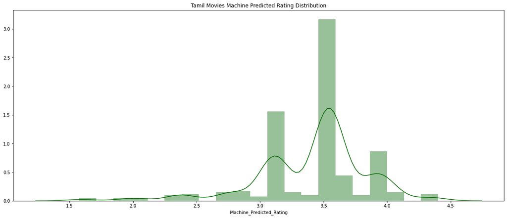

```python
plt.figure(figsize=(20,8))
chart3 = sb.distplot(final['Machine_Predicted_Rating'],  color="#006600")
chart3.set_title('Tamil Movies Machine Predicted Rating Distribution')
plt.show()
```

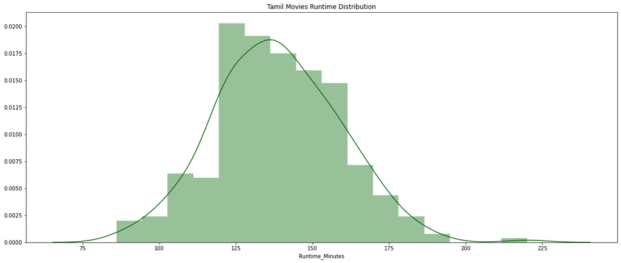

```python
plt.figure(figsize=(20,8))
chart4 = sb.distplot(dfx['Runtime_Minutes'],  color="#006600")
chart4.set_title('Tamil Movies Runtime Distribution')
plt.show()
```

```python
dfx['Runtime_Minutes'].mean()
```

```
138.54666666666665
```

```python
import matplotlib as mpl
```

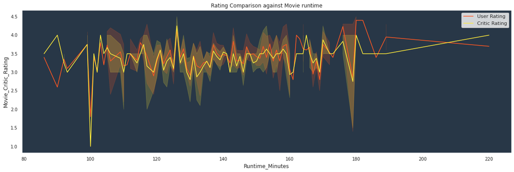

```python
plt.figure(figsize=(20,6))
sb.set(rc={"axes.facecolor":"#283747", "axes.grid":False,'xtick.labelsize':10,'ytick.labelsize':10})
chart5 = sb.lineplot(x=dfx.Runtime_Minutes,y=dfx.Movie_User_Rating,data=dfx, color="#FF5722", label='User Rating')
chart5 = sb.lineplot(x=dfx.Runtime_Minutes,y=dfx.Movie_Critic_Rating,data=dfx, color="#FFEB3B", label='Critic Rating')
chart5.set_title('Rating Comparison against Movie runtime')
legend = plt.legend()
frame = legend.get_frame()
frame.set_facecolor('white')
plt.show()
```

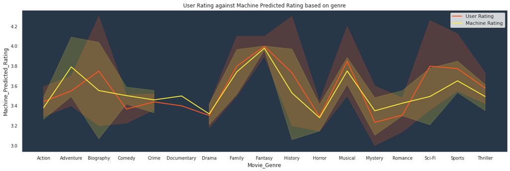

```python
plt.figure(figsize=(20,6))
chart6 = sb.lineplot(x=dfx.Movie_Genre,y=dfx.Movie_User_Rating, data=dfx, color = "#FF5722", linewidth=2, label='User Rating')
chart6 = sb.lineplot(x=dfx.Movie_Genre,y=dfx.Machine_Predicted_Rating, data=dfx, color = "#FFEB3B", linewidth=2, label='Machine Rating')
chart6.set_title('User Rating against Machine Predicted Rating based on genre')
legend = plt.legend()
frame = legend.get_frame()
frame.set_facecolor('white')
plt.show()
```

```python
mpl.rcParams.update(mpl.rcParamsDefault)
%matplotlib inline
sb.set_style("darkgrid")
```

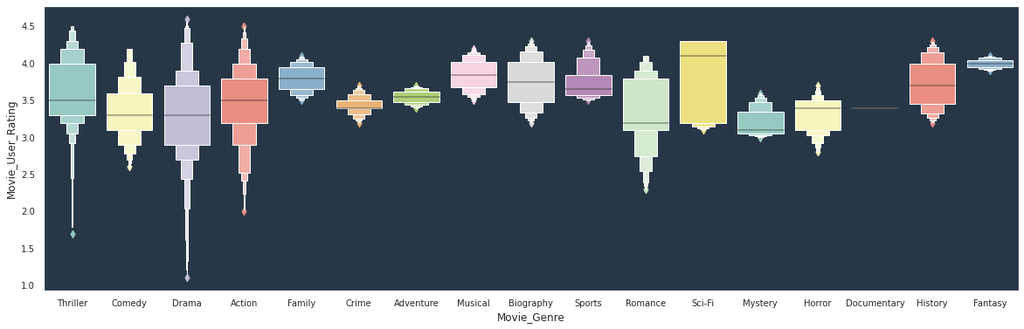

```python
plt.figure(figsize=(20,6))
sb.set(rc={"axes.facecolor":"#283747", "axes.grid":False,'xtick.labelsize':10,'ytick.labelsize':10})
sb.boxenplot(x=dfx.Movie_Genre, y=dfx.Movie_User_Rating, palette="Set3")
plt.show()
```

```python
'''plt.figure(figsize=(20,6))
sb.set(rc={"axes.facecolor":"white", "axes.grid":False,'xtick.labelsize':10,'ytick.labelsize':10})
sb.boxenplot(x=dfx.Movie_Genre, y=dfx.Movie_User_Rating, palette="Set2")
plt.show()'''
```

```
'plt.figure(figsize=(20,6))\nsb.set(rc={"axes.facecolor":"white", "axes.grid":False,\'xtick.labelsize\':10,\'ytick.labelsize\':10})\nsb.boxenplot(x=dfx.Movie_Genre, y=dfx.Movie_User_Rating, palette="Set2")\nplt.show()'
```

# Survey Analysis

We conducted a survey among our circles and it can be analysed as follows.

```python
survey = pd.read_excel('/Survey.xlsx')
survey.head()
```

|  | S.0 | Name | Horror | Romance | Action-Thriller | Comedy | Sports-based | Drama | Impact of Music | Social Awareness | Reviewer Influence |
| --- | --- | --- | --- | --- | --- | --- | --- | --- | --- | --- | --- |
| 0 | 1 | Kishan | 4 | 2 | 5 | 5 | 3 | 5 | 1 | 0 | 1 |
| 1 | 2 | Abhirami | 5 | 3 | 5 | 5 | 2 | 3 | 1 | 0 | 0 |
| 2 | 3 | Jaffar | 5 | 1 | 5 | 5 | 3 | 3 | 1 | 1 | 0 |
| 3 | 4 | Premalatha | 4 | 5 | 4 | 4 | 3 | 2 | 1 | 1 | 1 |
| 4 | 5 | K.Hariharan | 4 | 4 | 5 | 5 | 4 | 4 | 0 | 0 | 0 |

```python
survey = survey.drop(['S.0','Name'], axis = 'columns')
survey.head()
```

|  | Horror | Romance | Action-Thriller | Comedy | Sports-based | Drama | Impact of Music | Social Awareness | Reviewer Influence |
| --- | --- | --- | --- | --- | --- | --- | --- | --- | --- |
| 0 | 4 | 2 | 5 | 5 | 3 | 5 | 1 | 0 | 1 |
| 1 | 5 | 3 | 5 | 5 | 2 | 3 | 1 | 0 | 0 |
| 2 | 5 | 1 | 5 | 5 | 3 | 3 | 1 | 1 | 0 |
| 3 | 4 | 5 | 4 | 4 | 3 | 2 | 1 | 1 | 1 |
| 4 | 4 | 4 | 5 | 5 | 4 | 4 | 0 | 0 | 0 |

```python
survey['Horror'].sum()
```

```
197
```

```python
survey['Action-Thriller'].sum()
```

```
211
```

```python
survey['Comedy'].sum()
```

```
193
```

```python
survey['Sports-based'].sum()
```

```
188
```

```python
survey['Drama'].sum()
```

```
200
```

```python
survey['Romance'].sum()
```

```
175
```

```python
survey_genre = ['Horror','Action-Thriller','Romance','Comedy','Sports-based','Drama']
survey_values = [197,211,175,193,188,200]
```

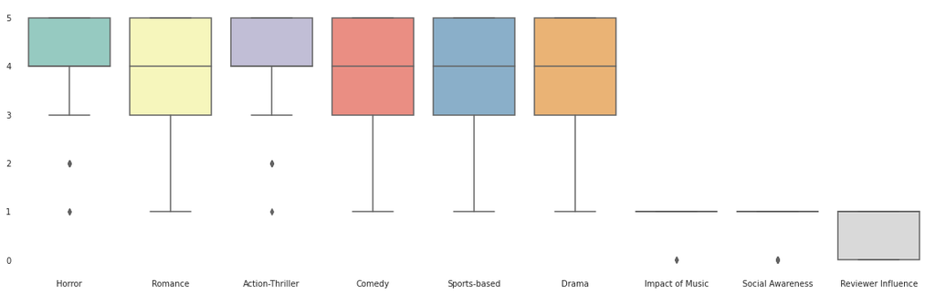

```python
plt.figure(figsize=(20,6))
sb.set(rc={"axes.facecolor":"white", "axes.grid":False,'xtick.labelsize':10,'ytick.labelsize':10})
sb.boxplot(data=survey, palette="Set3")
```

# Survey Conclusion

The sample that we selected had very similar interests. It explains that they prefer the presence of every aspect of every genre in general.

So our audience would like to watch a movie with every element of art in it like a combo of flavours. They would like to have a touch in every emotion they prefer.

Also, our audience feel like the presence of a strong social message in a film would be very much influential.

Majority of the audience also positively agree to the impact of music on the success of the movie.

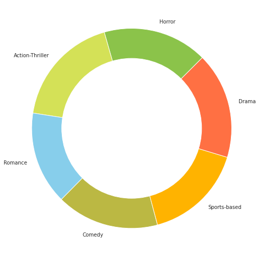

```python
plt.figure(figsize=(9,9))
survey_values = [197,211,175,193,188,200]
labels = ['Horror','Action-Thriller','Romance','Comedy','Sports-based','Drama']
colors = ['#8BC34A','#D4E157', 'skyblue','#BBB843','#FFB300','#FF7043']
plt.pie (survey_values , labels= labels , colors= colors , startangle=45)
my_circle=plt.Circle( (0,0), 0.7, color='white') # Adding circle at the centre
p=plt.gcf()
p.gca().add_artist(my_circle)
plt.show()
```